# Generating Secure Random Numbers in R

2018-07-30

2020-06-27

The `rand_bytes` function binds to [RAND_bytes](https://www.openssl.org/docs/manmaster/man3/RAND_bytes.html) in OpenSSL to generate cryptographically strong pseudo-random bytes. See the OpenSSL documentation for what this means.

```r
rnd <- rand_bytes(10)
print(rnd)
```

```
 [1] 89 1d 40 d3 51 48 6d 18 58 3e
```

Bytes are 8 bit and hence can have `2^8 = 256` possible values.

```r
as.numeric(rnd)
```

```
 [1] 137  29  64 211  81  72 109  24  88  62
```

Each random byte can be decomposed into 8 random bits (booleans)

```r
x <- rand_bytes(1)
as.logical(rawToBits(x))
```

```
[1]  TRUE FALSE FALSE FALSE FALSE  TRUE  TRUE  TRUE
```

[output not shown]

Bytes are 8 bit and hence can have `2^8 = 256` possible values.

```r
as.numeric(rnd)
```

[output not shown]

Each random byte can be decomposed into 8 random bits (booleans)

```r
x <- rand_bytes(1)
as.logical(rawToBits(x))
```

```
[1]  TRUE  TRUE FALSE FALSE  TRUE  TRUE  TRUE  TRUE
```

## Secure Random Numbers

`rand_num` is a simple (2 lines) wrapper to `rand_bytes` to generate random numbers (doubles) between 0 and 1.

```r
rand_num(10)
```

```
 [1] 0.01381206 0.48168439 0.62273228 0.37734622 0.36709521 0.87309426
 [7] 0.94449116 0.42901072 0.20627438 0.07521226
```

[output not shown]

To map random draws from [0,1] into a probability density, we can use a [Cumulative Distribution Function](http://en.wikipedia.org/wiki/Cumulative_distribution_function). For example we can combine `qnorm` and `rand_num` to simulate `rnorm`:

```r
# Secure rnorm
x <- qnorm(rand_num(1000), mean = 100, sd = 15)
hist(x)
```

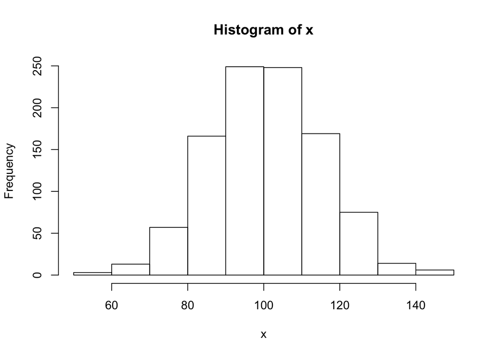

[figure not shown]

Same for discrete distributions:

```r
# Secure rbinom
y <- qbinom(rand_num(1000), size = 20, prob = 0.1)
hist(y, breaks = -.5:(max(y)+1))
```

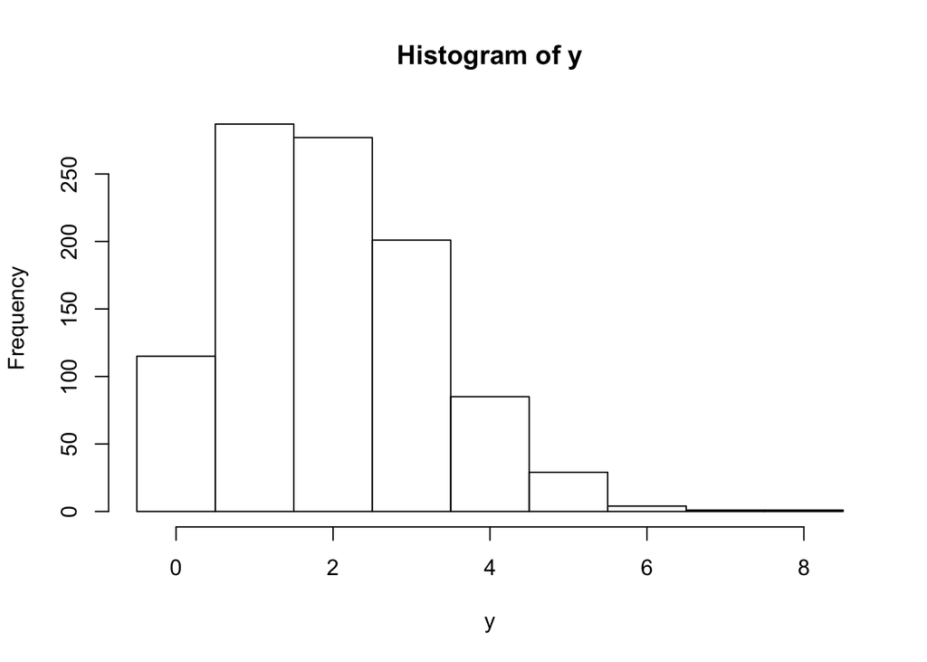

[figure not shown]